# Using lattice’s densityplot()

# Preliminaries

The function `densityplot()` is used to study the distribution of a numerical variable. It comes from the `lattice` package for statistical graphics, which is pre-installed with every distribution of R. Also, package `tigerstats` depends on lattice, so if you load `tigerstats`:

```r
require(tigerstats)
```

then `lattice` will be loaded as well.

# One Numerical Variable

In the `m11survey` data frame from the `tigerstats` package, suppose that you want to study the distribution of **fastest**, the fastest speed one has ever driven. You can do so with the following command:

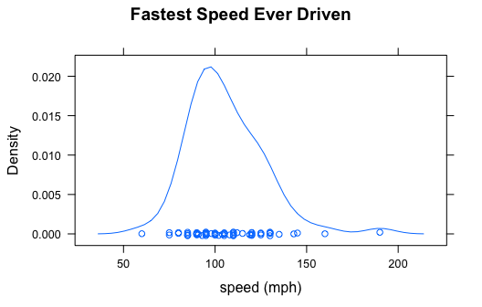

```r
densityplot(~fastest,data=m111survey,
       xlab="speed (mph)",
       main="Fastest Speed Ever Driven")
```

Note the use of:

- the `xlab` argument to label the horizontal axis, complete with units (miles per hour);
- the `main` argument to provide a brief but descriptive title for the graph.

If you do not want to see the “rug” of individual data values at the bottom of the plot, set the argument `plot.points` to `FALSE`:

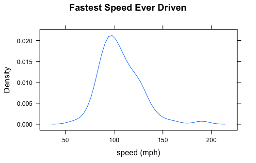

```r
densityplot(~fastest,data=m111survey,
       xlab="speed (mph)",
       main="Fastest Speed Ever Driven",
       plot.points=FALSE)
```

# Numerical and Factor Variable

Suppose you want to know:

> *Who tends to drive faster: guys or gals?*

Then you might wish to study the relationship between the numerical variable **fastest** and the factor variable **sex**. You can use density plots in two ways in order to perform such a study.

## Separate Panels

You can get a density plot for each vlaue of the favtor variable:

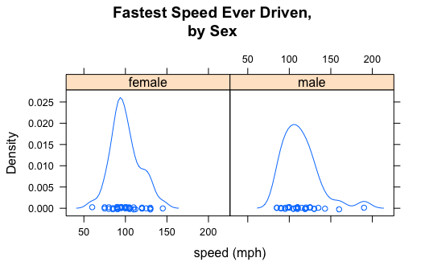

```r
densityplot(~fastest|sex,data=m111survey,
       xlab="speed (mph)",
       main="Fastest Speed Ever Driven,\nby Sex")
```

Note that to produce separate plots, you “condition” on the factor variable with the formula:

$\sim numerical \vert factor$

You can determine the layout of the separate plots with the `layout` argument:

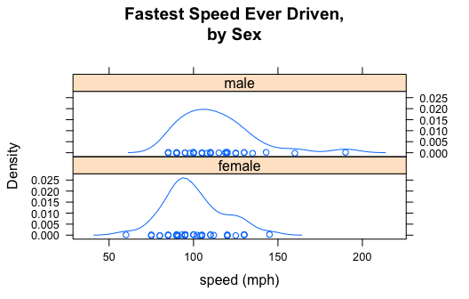

```r
densityplot(~fastest|sex,data=m111survey,
       xlab="speed (mph)",
       main="Fastest Speed Ever Driven,\nby Sex",
       layout=c(1,2))
```

Here in the list `c(1,2)`, the “1” says that you want one column, and the “2” says you want two rows.

## Plots in the Same Panel

You can get a density plot for each value of the factor variable and have all of the plots appear in the same panel. This is accomplished with the `groups` argument:

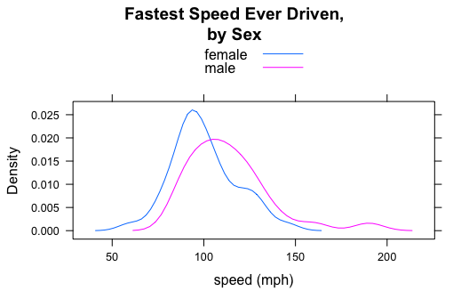

```r
densityplot(~fastest,data=m111survey,
       groups=sex,
       xlab="speed (mph)",
       main="Fastest Speed Ever Driven,\nby Sex",
       plot.points=FALSE,
       auto.key=TRUE)
```

Note the use of the `auto,key` argument to produce the legend at the top, so that the reader can tell which plot goes with which sex.

Many people think that grouped density plots allow for easier comparison than side-by-side plots do—at least if the number of groups is small.

# From and To

In the `imagpop` data frame, the variable **kkardashtemp** records the rating given, by each individual in the data frame, for the celebrity Kim Kardashian. The possible ratings range from 0 to 100.

Let’s make a density plot of this variable:

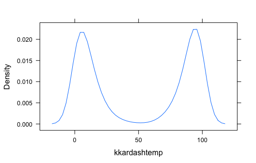

```r
densityplot(~kkardashtemp,data=imagpop,
            plot.points=FALSE)
```

The function `densityplot()` has no way of knowing that **kkardashtemp** must lie between 0 and 100, so from the available data it infers that there is some possibility for a rating to be below 0 or above 100. If you want to inform `denistyplot()` of the known limits, then use the `from` and `to` arguments, as follows:

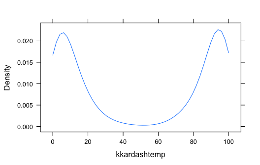

```r
densityplot(~kkardashtemp,data=imagpop,
            plot.points=FALSE,
            from=0,to=100)
```